# ANA 1005: Enterprise Analytics Final Assignment

Team Name: Anaconda  
Team Members:

Himanshi Bairagi: A00263144

Nallinie Khandare: A00247822

Vatsal Gala: A00240969

Vishal Bhataria: A00244248

The study is about a dataset containing shopping information from 10 different shopping malls in Istanbul between 2021 and 2023.  
The goal is to perform exploratory data analysis to identify shopping trends and patterns in Istanbul, and to generate actionable insights for the intended audience.  
The audience's needs include identifying customers' spending behavior based on demographic factors like age and gender, determining customers' preferred payment methods, and identifying the best-performing shopping malls in Istanbul.

Data Dictionary:

Invoice no: Invoice number. Nominal. A combination of the letter 'I' and a 6-digit integer is uniquely assigned to each operation.

Customer Id: Customer number. Nominal. A combination of the letter 'C' and a 6-digit integer is uniquely assigned to each operation.

Gender: String variable of the customer's gender.

Age: Positive Integer variable of the customer’s age.

Category: String variable of the category of the purchased product.

Quantity: The quantity of each product (item) per transaction. Numeric.

Price: Unit price. Numeric. Product price per unit in Turkish Liras (TL).

Payment Method: String variable of the payment method (cash, credit card or debit card) used for the transaction.

Invoice Date: The day when a transaction was generated.

Shopping Mall: String variable of the name of the shopping mall where the transaction was made

## Part 1: Exploratory Analysis

```python
# import all libraries here
import pandas as pd
import numpy as np
import matplotlib.pyplot as plt
import seaborn as sns
from scipy import stats
from scipy.stats import norm, kurtosis
from statsmodels.graphics.gofplots import qqplot

import warnings
warnings.filterwarnings('ignore')
```

```python
main_df = pd.read_csv("customer_shopping_data.csv")
df = main_df.copy() #creating a copy to investigate the orignal data after pre-processing
df.head()
```

|  | invoice_no | customer_id | gender | age | category | quantity | price | payment_method | invoice_date | shopping_mall |
| --- | --- | --- | --- | --- | --- | --- | --- | --- | --- | --- |
| 0 | I138884 | C241288 | Female | 28.0 | Clothing | 5 | 1500.40 | Credit Card | 05-08-2022 | Kanyon |
| 1 | I317333 | C111565 | Male | 21.0 | Shoes | 3 | 1800.51 | Debit Card | 12-12-2021 | Forum Istanbul |
| 2 | I127801 | C266599 | Male | 20.0 | Clothing | 1 | 300.08 | Cash | 09-11-2021 | Metrocity |
| 3 | I173702 | C988172 | Female | 66.0 | Shoes | 5 | 3000.85 | Credit Card | 16-05-2021 | Metropol AVM |
| 4 | I337046 | C189076 | Female | 53.0 | Books | 4 | 60.60 | Cash | 24-10-2021 | Kanyon |

```python
# identify the shape of the data
print(f"Number of rows: {df.shape[0]}")
print(f"Number of columns: {df.shape[1]}")
```

```
Number of rows: 99457
Number of columns: 10
```

```python
# adding a total sales column
df["total_sale"] = df["quantity"]*df["price"]
df.head()
```

|  | invoice_no | customer_id | gender | age | category | quantity | price | payment_method | invoice_date | shopping_mall | total_sale |
| --- | --- | --- | --- | --- | --- | --- | --- | --- | --- | --- | --- |
| 0 | I138884 | C241288 | Female | 28.0 | Clothing | 5 | 1500.40 | Credit Card | 05-08-2022 | Kanyon | 7502.00 |
| 1 | I317333 | C111565 | Male | 21.0 | Shoes | 3 | 1800.51 | Debit Card | 12-12-2021 | Forum Istanbul | 5401.53 |
| 2 | I127801 | C266599 | Male | 20.0 | Clothing | 1 | 300.08 | Cash | 09-11-2021 | Metrocity | 300.08 |
| 3 | I173702 | C988172 | Female | 66.0 | Shoes | 5 | 3000.85 | Credit Card | 16-05-2021 | Metropol AVM | 15004.25 |
| 4 | I337046 | C189076 | Female | 53.0 | Books | 4 | 60.60 | Cash | 24-10-2021 | Kanyon | 242.40 |

```python
# identify if the data has any null values
print(df.isnull().sum())
```

```
invoice_no           0
customer_id          0
gender               0
age               3683
category             0
quantity             0
price                0
payment_method       0
invoice_date         0
shopping_mall        0
total_sale           0
dtype: int64
```

```python
# treating missing values (since only less than 10% of the total data is missing, we will impute it using the mean)
mean_age = df['age'].mean()
df['age'] = df['age'].fillna(mean_age)
```

```python
# validate if the data has any null values
print(df.isnull().sum())
```

```
invoice_no        0
customer_id       0
gender            0
age               0
category          0
quantity          0
price             0
payment_method    0
invoice_date      0
shopping_mall     0
total_sale        0
dtype: int64
```

```python
# identify the data type
print(df.dtypes)
```

```
invoice_no         object
customer_id        object
gender             object
age               float64
category           object
quantity            int64
price             float64
payment_method     object
invoice_date       object
shopping_mall      object
total_sale        float64
dtype: object
```

```python
# converting the data according to suitable data type
df['age'] = df['age'].astype(int)
df['invoice_date'] = pd.to_datetime(df['invoice_date'])
```

```python
# validate the data type
print(df.dtypes)
```

```
invoice_no                object
customer_id               object
gender                    object
age                        int32
category                  object
quantity                   int64
price                    float64
payment_method            object
invoice_date      datetime64[ns]
shopping_mall             object
total_sale               float64
dtype: object
```

```python
# identify the unique values in our data set
df.apply(lambda df:len(df.unique()))
```

```
invoice_no        99457
customer_id       99457
gender                2
age                  52
category              8
quantity              5
price               793
payment_method        3
invoice_date        797
shopping_mall        10
total_sale          816
dtype: int64
```

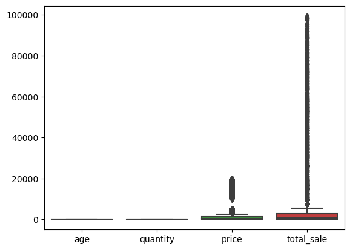

```python
sns.boxplot(data=df)
```

We use the boxplot here to identify if there are any outliers present in our dataset  
We can identify that:

"age" and "quantity" have no visible outliers

"total_sale" and "price" variable has extreme visible ouliers  
This information allows us to check the outliers present in the data

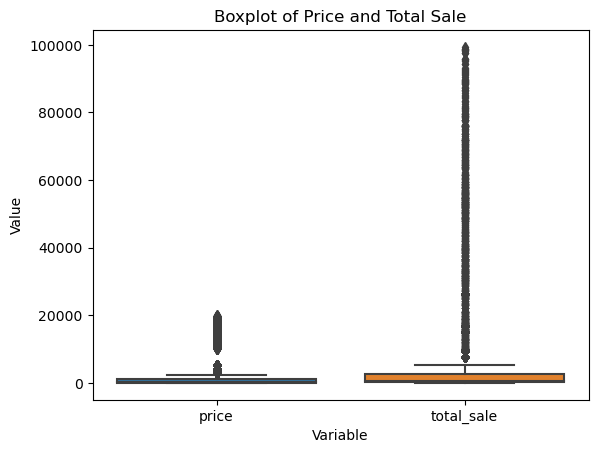

```python
sns.boxplot(data=df[["price", "total_sale"]])
plt.title("Boxplot of Price and Total Sale")
plt.xlabel("Variable")
plt.ylabel("Value")
plt.show()
```

```python
# calculate IQR and upper/lower bounds for price and total_sale
q1 = df.quantile(0.25)
q3 = df.quantile(0.75)
iqr = q3 - q1
lower_bound = q1 - 1.5 * iqr
upper_bound = q3 + 1.5 * iqr

# replace outliers with upper/lower bounds
df['price'] = np.where(df['price'] > upper_bound['price'], upper_bound['price'], df['price'])
df['price'] = np.where(df['price'] < lower_bound['price'], lower_bound['price'], df['price'])
df['total_sale'] = np.where(df['total_sale'] > upper_bound['total_sale'], upper_bound['total_sale'], df['total_sale'])
df['total_sale'] = np.where(df['total_sale'] < lower_bound['total_sale'], lower_bound['total_sale'], df['total_sale'])
```

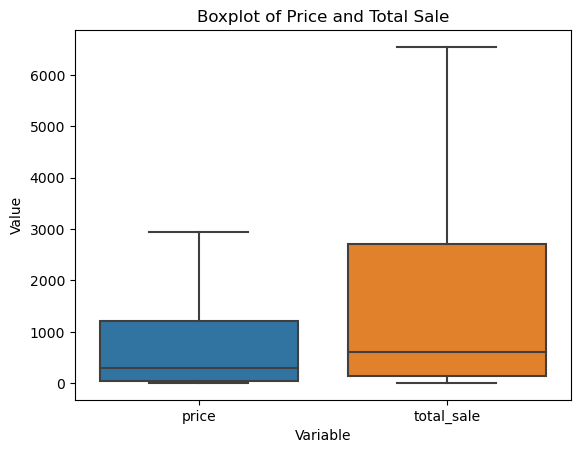

```python
sns.boxplot(data=df[["price", "total_sale"]])
plt.title("Boxplot of Price and Total Sale")
plt.xlabel("Variable")
plt.ylabel("Value")
plt.show()
```

### Create KPIs

```python
# average price per unit for each category
avg_price_per_unit = df.groupby('category')['price'].mean().sort_values(ascending=False)

print("\nAverage Price per Unit by Category:\n", avg_price_per_unit)
```

```
Average Price per Unit by Category:
 category
Technology         2399.307146
Shoes              1805.439654
Clothing            918.464189
Cosmetics           144.972795
Toys                128.986821
Books                63.543470
Souvenir             55.180447
Food & Beverage      34.222502
Name: price, dtype: float64
```

```python
# percentage of transactions paid via cash, debit, or credit card
cash_percent = df[df['payment_method'] == 'Cash'].shape[0] / df.shape[0] * 100
debit_card_percent = df[df['payment_method'] == 'Debit Card'].shape[0] / df.shape[0] * 100
credit_card_percent = df[df['payment_method'] == 'Credit Card'].shape[0] / df.shape[0] * 100

print("\nPercentage of Transactions Paid with Cash: {:.2f}%".format(cash_percent))
print("\nPercentage of Transactions Paid with Debit Card: {:.2f}%".format(debit_card_percent))
print("\nPercentage of Transactions Paid with Credit Card: {:.2f}%".format(credit_card_percent))
```

```
Percentage of Transactions Paid with Cash: 44.69%

Percentage of Transactions Paid with Debit Card: 20.19%

Percentage of Transactions Paid with Credit Card: 35.12%
```

```python
# average age of customers for each shopping mall
avg_age = df.groupby('shopping_mall')['age'].mean().sort_values(ascending=False)

print("\nAverage Age by Shopping Mall:\n", avg_age)
```

```
Average Age by Shopping Mall:
 shopping_mall
Emaar Square Mall    43.531075
Kanyon               43.511830
Zorlu Center         43.491626
Forum Istanbul       43.470386
Metrocity            43.468190
Mall of Istanbul     43.411974
Istinye Park         43.363153
Viaport Outlet       43.212047
Metropol AVM         43.169964
Cevahir AVM          43.164696
Name: age, dtype: float64
```

```python
# number of transactions for each category
num_transactions = df['category'].value_counts().sort_values(ascending=False)

print("\nNumber of Transactions by Category:\n", num_transactions)
```

```
Number of Transactions by Category:
 Clothing           34487
Cosmetics          15097
Food & Beverage    14776
Toys               10087
Shoes              10034
Souvenir            4999
Technology          4996
Books               4981
Name: category, dtype: int64
```

## Part 2: Analyzing the distribution of data

```python
# creating a copy to analyze the distribution of data
df_dist = df.copy()
df_dist.head()
```

|  | invoice_no | customer_id | gender | age | category | quantity | price | payment_method | invoice_date | shopping_mall | total_sale |
| --- | --- | --- | --- | --- | --- | --- | --- | --- | --- | --- | --- |
| 0 | I138884 | C241288 | Female | 28 | Clothing | 5 | 1500.400 | Credit Card | 2022-05-08 | Kanyon | 6547.275 |
| 1 | I317333 | C111565 | Male | 21 | Shoes | 3 | 1800.510 | Debit Card | 2021-12-12 | Forum Istanbul | 5401.530 |
| 2 | I127801 | C266599 | Male | 20 | Clothing | 1 | 300.080 | Cash | 2021-09-11 | Metrocity | 300.080 |
| 3 | I173702 | C988172 | Female | 66 | Shoes | 5 | 2932.625 | Credit Card | 2021-05-16 | Metropol AVM | 6547.275 |
| 4 | I337046 | C189076 | Female | 53 | Books | 4 | 60.600 | Cash | 2021-10-24 | Kanyon | 242.400 |

### 1. Skew and Kurtosis

```python
# inititate dictionaries to store skew and kurtosis of data
skew_dict = {}
kurt_dict = {}

# list of columns to be analyzed
sub_cols = ['age','quantity','price','total_sale']

# calculate skew and kurtosis of each column
for column in sub_cols:
    skew_dict[column] = df_dist[column].skew()
    kurt_dict[column] = df_dist[column].kurtosis()

# print skew and kurtosis of each column
for column in sub_cols:
    print('Skew = ', round(skew_dict[column],5), '| Kurtosis = ', round(kurt_dict[column],5), ' <- ', column)
```

```
Skew =  0.01302 | Kurtosis =  -1.1289  <-  age
Skew =  -0.0013 | Kurtosis =  -1.29589  <-  quantity
Skew =  1.41891 | Kurtosis =  1.20104  <-  price
Skew =  1.03075 | Kurtosis =  -0.57724  <-  total_sale
```

**Skew and Kurtosis interpretation**  
*Note: Pandas' kurtosis function uses Fisher’s definition of kurtosis (kurtosis of normal == 0.0) and produces excess kurtosis as the output. Since the normal distributions have a kurtosis of 3, excess kurtosis is calculated by subtracting kurtosis by 3.*

"price"  
=> The high positive value skew (1.41891) value implies that the distribution is positively skewed.  
=> Kurtosis (1.20104) > 0, which means the distribution is "Leptokurtic" and most data points are present in the tails.

"total_sale"  
=> The high positive value skew (1.03075) value implies that the distribution is is positively skewed.  
=> Kurtosis (-0.57724) < 0, which means the distribution is "Platykurtic" and most data points are present in high proximity to the mean.

### 2. Visual interpretation - Histogram, Boxplot, and QQ plot

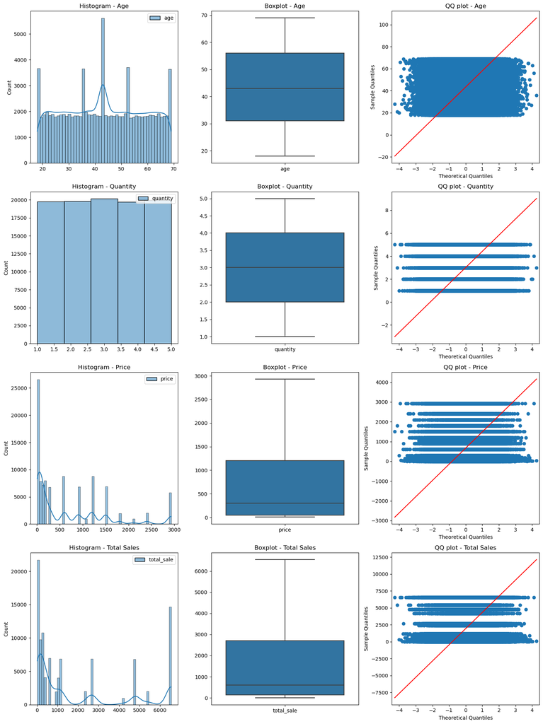

```python
# histogram, boxplot and qqp plot
fig, axs = plt.subplots(nrows=4,ncols=3, figsize=(15,20))

# age
sns.histplot(data=df_dist[['age']], kde=True, ax=axs[0,0])
axs[0,0].set_title('Histogram - Age')
sns.boxplot(data=df_dist[['age']], ax=axs[0,1])
axs[0,1].set_title('Boxplot - Age')
qqplot(data=df_dist[['age']], line='s', ax=axs[0,2])
axs[0,2].set_title('QQ plot - Age')

# quantity
sns.histplot(data=df_dist[['quantity']], kde=False, bins =5, ax=axs[1,0])
axs[1,0].set_title('Histogram - Quantity')
sns.boxplot(data=df_dist[['quantity']], ax=axs[1,1])
axs[1,1].set_title('Boxplot - Quantity')
qqplot(data=df_dist[['quantity']], line='s', ax=axs[1,2])
axs[1,2].set_title('QQ plot - Quantity')

# price
sns.histplot(data=df_dist[['price']], kde=True, ax=axs[2,0])
axs[2,0].set_title('Histogram - Price')
sns.boxplot(data=df_dist[['price']], ax=axs[2,1])
axs[2,1].set_title('Boxplot - Price')
qqplot(data=df_dist[['price']], line='s', ax=axs[2,2])
axs[2,2].set_title('QQ plot - Price')

# total slaes
sns.histplot(data=df_dist[['total_sale']], kde=True, ax=axs[3,0])
axs[3,0].set_title('Histogram - Total Sales')
sns.boxplot(data=df_dist[['total_sale']], ax=axs[3,1])
axs[3,1].set_title('Boxplot - Total Sales')
qqplot(data=df_dist[['total_sale']], line='s', ax=axs[3,2])
axs[3,2].set_title('QQ plot - Total Sales')

fig.tight_layout()
plt.show()
```

### 3. Test of normality

```python
# inititate dictionaries to store statistic and pvalue of the data calculated using scipy.stats.normaltest
stat_dict = {}
p_dict = {}

# list of columns to be analyzed
sub_cols = ['age','quantity','price','total_sale']

# calculate skew and kurtosis of each column
for column in sub_cols:
    stat_dict[column], p_dict[column] = stats.normaltest(df_dist[column])

# choose alpha value
alpha = 0.05

# print skew and kurtosis of each column
for column in sub_cols:
    print("\n")
    print("Normality Test for variable:", column, "=> statistic: ", stat_dict[column], "| p-value: ", p_dict[column])

    # null hypothesis: x comes from a normal distribution
    if p_dict[column] < alpha:
        print("Reject the null hypothesis - ", column ," does not comes from a normal distribution")
    else:
        print("Fail to reject the null hypothesis - ", column ," comes from a normal distribution")
```

```
Normality Test for variable: age => statistic:  49932.6174503556 | p-value:  0.0
Reject the null hypothesis -  age  does not comes from a normal distribution


Normality Test for variable: quantity => statistic:  345030.9448028458 | p-value:  0.0
Reject the null hypothesis -  quantity  does not comes from a normal distribution


Normality Test for variable: price => statistic:  21718.395456377053 | p-value:  0.0
Reject the null hypothesis -  price  does not comes from a normal distribution


Normality Test for variable: total_sale => statistic:  15181.386704161108 | p-value:  0.0
Reject the null hypothesis -  total_sale  does not comes from a normal distribution
```

"scipy.stats.normaltest" tests the null hypothesis that a sample comes from a normal distribution. It is based on D’Agostino and Pearson’s test that combines skew and kurtosis to produce an omnibus test of normality.

### 4. Transforming skewed data

```python
# creating a copy to transform the skewed data
df_trfm = df.copy()
df_trfm.head()
```

|  | invoice_no | customer_id | gender | age | category | quantity | price | payment_method | invoice_date | shopping_mall | total_sale |
| --- | --- | --- | --- | --- | --- | --- | --- | --- | --- | --- | --- |
| 0 | I138884 | C241288 | Female | 28 | Clothing | 5 | 1500.400 | Credit Card | 2022-05-08 | Kanyon | 6547.275 |
| 1 | I317333 | C111565 | Male | 21 | Shoes | 3 | 1800.510 | Debit Card | 2021-12-12 | Forum Istanbul | 5401.530 |
| 2 | I127801 | C266599 | Male | 20 | Clothing | 1 | 300.080 | Cash | 2021-09-11 | Metrocity | 300.080 |
| 3 | I173702 | C988172 | Female | 66 | Shoes | 5 | 2932.625 | Credit Card | 2021-05-16 | Metropol AVM | 6547.275 |
| 4 | I337046 | C189076 | Female | 53 | Books | 4 | 60.600 | Cash | 2021-10-24 | Kanyon | 242.400 |

```python
# log transformation of price and total_sale columns
df_trfm['price_transformed'] = np.log(df_trfm['price'])
df_trfm['total_sale_transformed'] = np.log(df_trfm['total_sale'])

# square root transformation of price and total_sale columns
df_trfm['price_transformed_sqrrt'] = np.sqrt(df_trfm['price'])
df_trfm['total_sale_transformed_sqrrt'] = np.sqrt(df_trfm['total_sale'])
```

```python
# inititate dictionaries to store skew and kurtosis of data
trfm_skew_dict = {}
trfm_kurt_dict = {}

# list of columns to be analyzed
sub_cols = ['price_transformed','total_sale_transformed','price_transformed_sqrrt','total_sale_transformed_sqrrt']

# calculate skew and kurtosis of the tranformed data
for column in sub_cols:
    trfm_skew_dict[column] = df_trfm[column].skew()
    trfm_kurt_dict[column] = df_trfm[column].kurtosis()

# print skew and kurtosis of each column
for column in sub_cols:
    print('Skew = ', round(trfm_skew_dict[column],5), '| Kurtosis = ', round(trfm_kurt_dict[column],5), ' <- ', column)
```

```
Skew =  -0.30092 | Kurtosis =  -1.09232  <-  price_transformed
Skew =  -0.42017 | Kurtosis =  -0.73262  <-  total_sale_transformed
Skew =  0.63504 | Kurtosis =  -0.76694  <-  price_transformed_sqrrt
Skew =  0.61535 | Kurtosis =  -1.12489  <-  total_sale_transformed_sqrrt
```

The treatment with log transformation resulted in smaller skew values than square root transformed data.

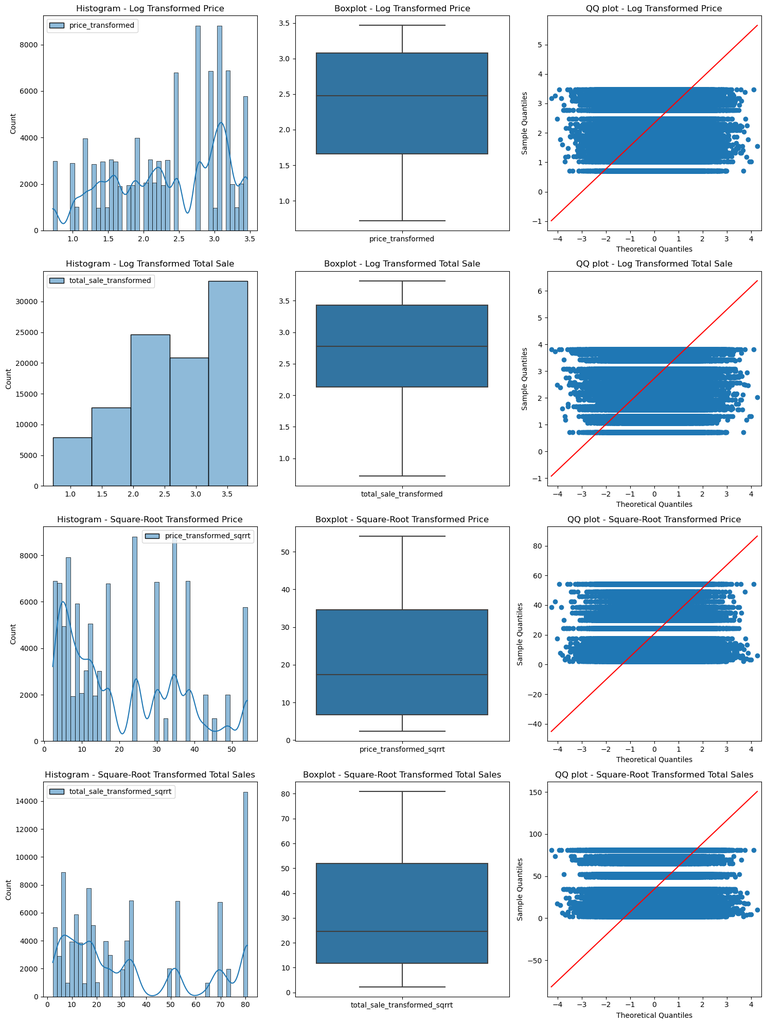

```python
# histogram, boxplot and qqp plot
fig, axs = plt.subplots(nrows=4,ncols=3, figsize=(15,20))

# price_transformed
sns.histplot(data=df_trfm[['price_transformed']], kde=True, ax=axs[0,0])
axs[0,0].set_title('Histogram - Log Transformed Price')
sns.boxplot(data=df_trfm[['price_transformed']], ax=axs[0,1])
axs[0,1].set_title('Boxplot - Log Transformed Price')
qqplot(data=df_trfm[['price_transformed']], line='s', ax=axs[0,2])
axs[0,2].set_title('QQ plot - Log Transformed Price')

# total_sale_transformed
sns.histplot(data=df_trfm[['total_sale_transformed']], kde=False, bins =5, ax=axs[1,0])
axs[1,0].set_title('Histogram - Log Transformed Total Sale')
sns.boxplot(data=df_trfm[['total_sale_transformed']], ax=axs[1,1])
axs[1,1].set_title('Boxplot - Log Transformed Total Sale')
qqplot(data=df_trfm[['total_sale_transformed']], line='s', ax=axs[1,2])
axs[1,2].set_title('QQ plot - Log Transformed Total Sale')

# price_transformed_sqrrt
sns.histplot(data=df_trfm[['price_transformed_sqrrt']], kde=True, ax=axs[2,0])
axs[2,0].set_title('Histogram - Square-Root Transformed Price')
sns.boxplot(data=df_trfm[['price_transformed_sqrrt']], ax=axs[2,1])
axs[2,1].set_title('Boxplot - Square-Root Transformed Price')
qqplot(data=df_trfm[['price_transformed_sqrrt']], line='s', ax=axs[2,2])
axs[2,2].set_title('QQ plot - Square-Root Transformed Price')

# total_sale_transformed_sqrrt
sns.histplot(data=df_trfm[['total_sale_transformed_sqrrt']], kde=True, ax=axs[3,0])
axs[3,0].set_title('Histogram - Square-Root Transformed Total Sales')
sns.boxplot(data=df_trfm[['total_sale_transformed_sqrrt']], ax=axs[3,1])
axs[3,1].set_title('Boxplot - Square-Root Transformed Total Sales')
qqplot(data=df_trfm[['total_sale_transformed_sqrrt']], line='s', ax=axs[3,2])
axs[3,2].set_title('QQ plot - Square-Root Transformed Total Sales')

fig.tight_layout()
plt.show()
```

## Part 3: Data Analysis and Insights

#### 1. Graphical Representation of Analysis

In this section, we will answer the below-mentioned problem statements for Istanbul's shopping data across its top ten shopping malls.

A. Overview of the performance of Istanbul's top ten shopping malls

1. Which shopping malls generated the most sales?
2. Which shopping categories generate the highest revenue for shopping malls?
3. What is the preferred mode of payment for the majority of customers?
4. Is there a seasonal component to the shopping trend?

B. Customer demographics and purchasing behaviour

1. Do Istanbul shopping centres appeal to particular gender?
2. Are there differences in the spending behaviours of people of different ages and genders?
3. Do people of different ages and genders have different purchasing preferences?
4. Do individuals of different ages and genders prefer different payment methods?

C. Projection of Istanbul's shopping market for the remaining months of 2023

###### Q. A(1): Which shopping malls generated the most sales?

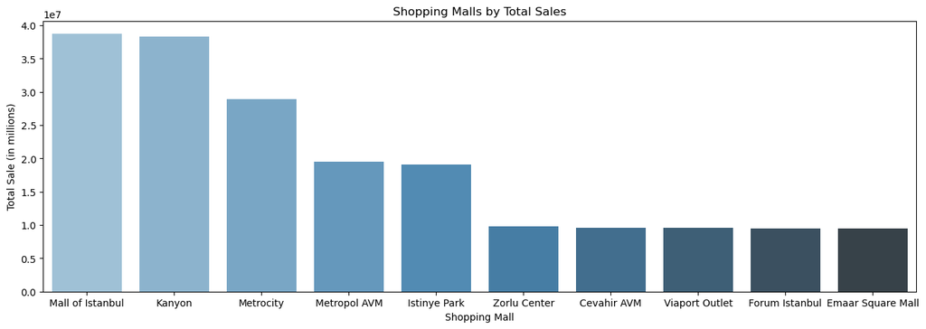

```python
# Groupby shopping mall and sum of total_sale
total_sale_by_mall = df.groupby('shopping_mall')['total_sale'].sum().sort_values(ascending=False)

# Plot bar chart of shopping malls by total sales
plt.figure(figsize=(16,5))
sns.barplot(x=total_sale_by_mall.index, y=total_sale_by_mall.values, palette='Blues_d')
plt.title('Shopping Malls by Total Sales')
plt.xlabel('Shopping Mall')
plt.ylabel('Total Sale (in millions)')
plt.show()
```

From the barplot above, we can identify that Kanyon and the Mall of Istanbul are the two shopping malls that generated the most sales

###### Q. A(2): Which shopping categories generate the highest revenue for shopping malls?

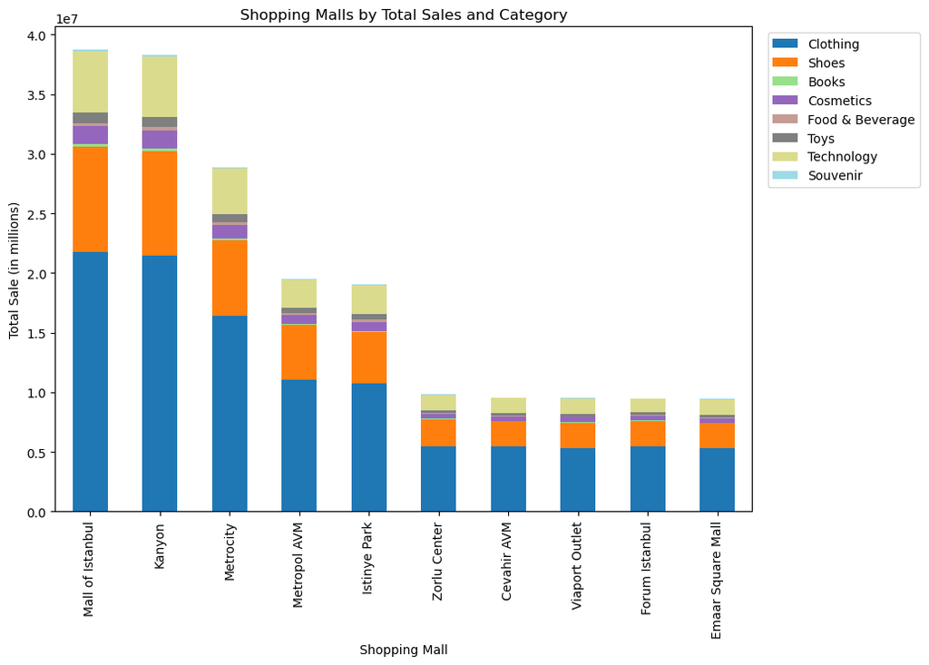

```python
# Groupby shopping mall and category, and sum of total_sale
total_sale_by_mall_category = df.groupby(['shopping_mall', 'category'])['total_sale'].sum()

# Plot stacked bar chart of top 10 shopping malls by total sales and category
top_10_malls = df.groupby('shopping_mall')['total_sale'].sum().sort_values(ascending=False)[:10].index.tolist()
top_10_categories = df['category'].unique().tolist()
data = total_sale_by_mall_category.unstack(level=-1)[top_10_categories].loc[top_10_malls]
data.plot(kind='bar', stacked=True, figsize=(10,7), colormap='tab20')
plt.title('Shopping Malls by Total Sales and Category')
plt.xlabel('Shopping Mall')
plt.ylabel('Total Sale (in millions)')
plt.legend(loc='upper right', bbox_to_anchor=(1.25, 1))
plt.show()
```

From the above stack chart, we can identify that Clothing followed by Shoes, generated the highest revenue for the shopping malls

###### Q. A(3): What is the preferred mode of payment for the majority of customers?

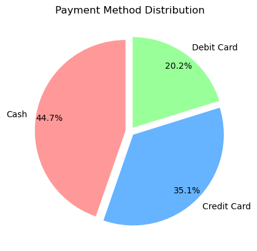

```python
# Groupby payment method and count of transactions
payment_method_count = df.groupby('payment_method')['customer_id'].count()

# Plot pie chart of payment method distribution
labels = payment_method_count.index.tolist()
sizes = payment_method_count.values.tolist()
colors = ['#ff9999','#66b3ff','#99ff99']
explode = (0.05, 0.05, 0.05)
plt.pie(sizes, labels=labels, colors=colors, autopct='%1.1f%%', startangle=90, pctdistance=0.85, explode=explode)
plt.title('Payment Method Distribution')
plt.show()
```

The above pie chart can be used to validate our finding that Cash is the most preferred method of payment in Istanbul

###### Q. A(4): Is there a seasonal component to the shopping trend?

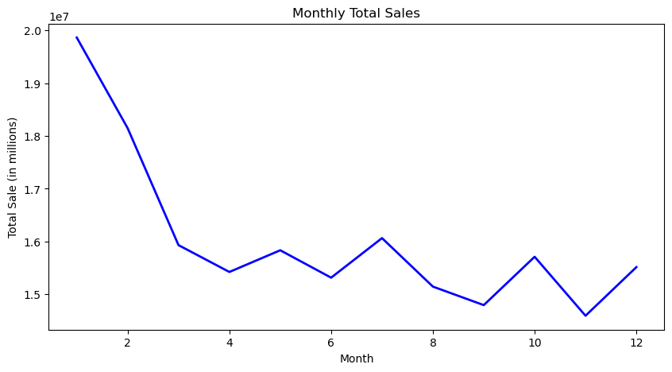

```python
# Create new column for month
df['month'] = df['invoice_date'].dt.month

# Groupby month and sum of total_sale
total_sale_by_month = df.groupby('month')['total_sale'].sum()

# Plot line chart of monthly total sales
plt.figure(figsize=(10,5))
sns.lineplot(x=total_sale_by_month.index, y=total_sale_by_month.values, color='b', linewidth=2)
plt.title('Monthly Total Sales')
plt.xlabel('Month')
plt.ylabel('Total Sale (in millions)')
plt.show()
```

There doesn't seem a very strong trend in the seasonal component to the shopping trend, however it can be observed that sales started to pick up from the end of the year and follows an observable drop after February

##### Q. (B)(1): Do Istanbul shopping centres appeal to particular gender?

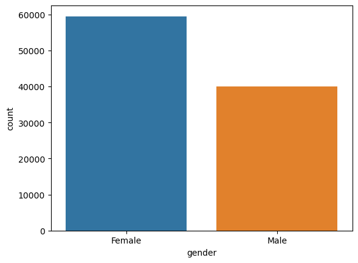

```python
sns.countplot(x='gender', data=df)
plt.show()
```

Using a countplot we can identify the demograpy distribution for gender, it also suggests that:

The mall's in Istanbul likely have more products that cater to the needs of a female shopper

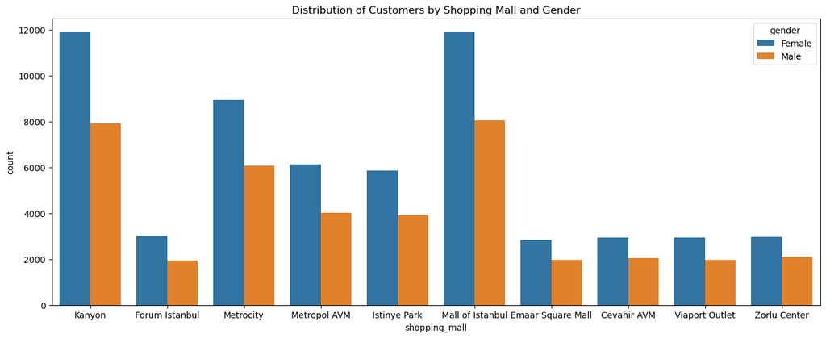

```python
plt.figure(figsize=(16, 6))
sns.countplot(x='shopping_mall', hue='gender', data=df)
plt.title('Distribution of Customers by Shopping Mall and Gender')
```

It can be observed that majority of the customers for the malls are females

##### Q. (B)(2): Are there differences in the spending behaviours of people of different ages and genders?

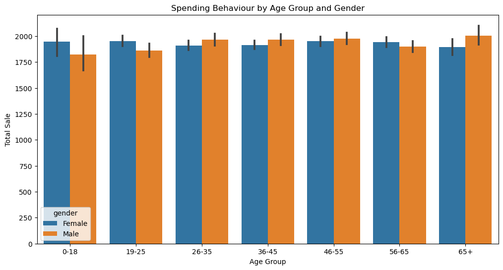

```python
# Define age bins
age_bins = [0, 18, 25, 35, 45, 55, 65, 100]

# Create age group labels
age_labels = ['0-18', '19-25', '26-35', '36-45', '46-55', '56-65', '65+']

# Add age group column to the dataframe
df['age_group'] = pd.cut(df['age'], bins=age_bins, labels=age_labels)

# Plot spending behaviour by age group and gender
plt.figure(figsize=(12, 6))
sns.barplot(x='age_group', y='total_sale', hue='gender', data=df)
plt.title('Spending Behaviour by Age Group and Gender')
plt.xlabel('Age Group')
plt.ylabel('Total Sale')
plt.show()
```

##### Q. (B)(3): Do people of different age and gender have different purchasing preferences?

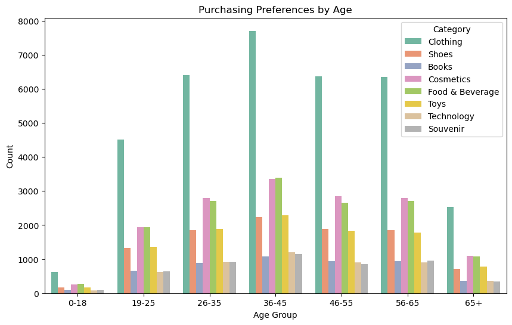

```python
# create a stacked bar plot of category by age and gender
plt.figure(figsize=(10, 6))
sns.countplot(x='age_group', hue='category', data=df, palette='Set2')
plt.title('Purchasing Preferences by Age')
plt.xlabel('Age Group')
plt.ylabel('Count')
plt.legend(title='Category', loc='upper right')
plt.show()
```

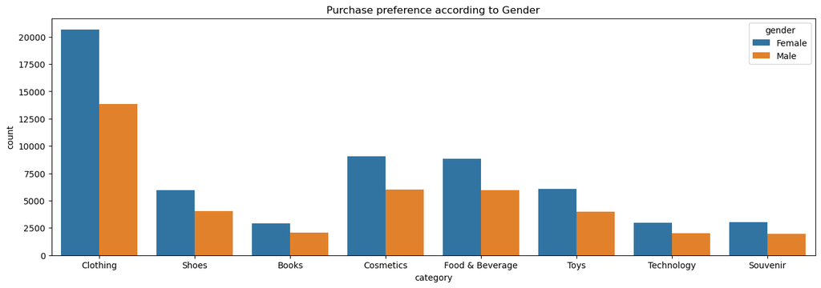

```python
plt.figure(figsize=(16, 5))
sns.countplot(x='category', hue='gender', data=df)
plt.title('Purchase preference according to Gender')

plt.show()
```

The charts above help us identify: Females shop more than Males

People between the age group 36-45 spend more on shopping at the malls

Clothing is the most sold product which is highly purchased by females

In all the category, females are likely to purchase more than males

##### Q. (B)(4): Do individuals of different ages and genders prefer different payment methods?

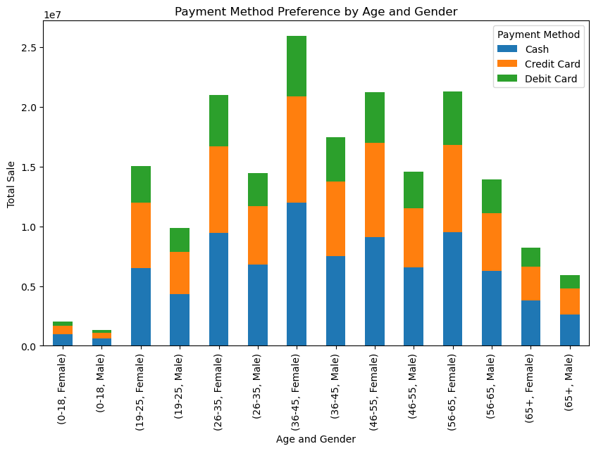

```python
# Group by age, gender, and payment method
payment_by_age_gender = df.groupby(['age_group', 'gender', 'payment_method'])['total_sale'].sum().reset_index()

# Pivot the data to create a stacked bar chart
payment_by_age_gender_pivot = payment_by_age_gender.pivot_table(index=['age_group', 'gender'], columns='payment_method', values='total_sale')

# Plot the stacked bar chart
payment_by_age_gender_pivot.plot(kind='bar', stacked=True, figsize=(10, 6))
plt.title('Payment Method Preference by Age and Gender')
plt.xlabel('Age and Gender')
plt.ylabel('Total Sale')
plt.legend(title='Payment Method')
plt.show()
```

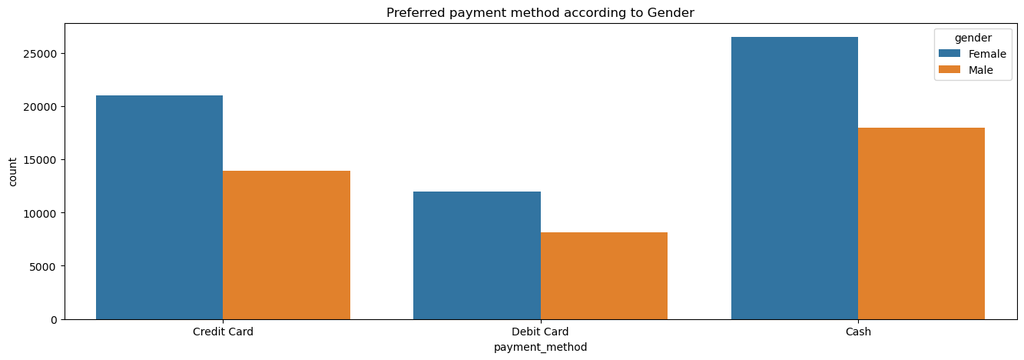

```python
plt.figure(figsize=(16, 5))
sns.countplot(x='payment_method', hue='gender', data=df)
plt.title('Preferred payment method according to Gender')

plt.show()
```

It suggests that the people of all age group follow a similar pattern of paying through cash over cards.

It also indicates that cash is preferred more both by males and females

##### Q. (C): Projection of Istanbul's shopping market for the remainder of 2023

```python
# import libraries
import warnings
import itertools
import numpy as np
import matplotlib.pyplot as plt
warnings.filterwarnings("ignore")
plt.style.use('fivethirtyeight')
import pandas as pd
import statsmodels.api as sm
import matplotlib
matplotlib.rcParams['axes.labelsize'] = 14
matplotlib.rcParams['xtick.labelsize'] = 12
matplotlib.rcParams['ytick.labelsize'] = 12
matplotlib.rcParams['text.color'] = 'k'
```

```python
# creating a copy to analyze the distribution of data
df_proj = df.copy()
df_proj.head()
```

|  | invoice_no | customer_id | gender | age | category | quantity | price | payment_method | invoice_date | shopping_mall | total_sale | month | age_group |
| --- | --- | --- | --- | --- | --- | --- | --- | --- | --- | --- | --- | --- | --- |
| 0 | I138884 | C241288 | Female | 28 | Clothing | 5 | 1500.400 | Credit Card | 2022-05-08 | Kanyon | 6547.275 | 5 | 26-35 |
| 1 | I317333 | C111565 | Male | 21 | Shoes | 3 | 1800.510 | Debit Card | 2021-12-12 | Forum Istanbul | 5401.530 | 12 | 19-25 |
| 2 | I127801 | C266599 | Male | 20 | Clothing | 1 | 300.080 | Cash | 2021-09-11 | Metrocity | 300.080 | 9 | 19-25 |
| 3 | I173702 | C988172 | Female | 66 | Shoes | 5 | 2932.625 | Credit Card | 2021-05-16 | Metropol AVM | 6547.275 | 5 | 65+ |
| 4 | I337046 | C189076 | Female | 53 | Books | 4 | 60.600 | Cash | 2021-10-24 | Kanyon | 242.400 | 10 | 46-55 |

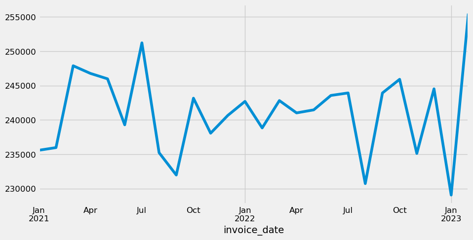

```python
# change data type of invoice_date to date format
df_proj['invoice_date'] = pd.to_datetime(df_proj['invoice_date'], format= "%d-%m-%Y" )

# filter datset
df_proj_clean = df_proj[(df_proj['invoice_date'] < '2023-03-01')]

# aggregate sum of sales at date level
total_sales = df_proj_clean.groupby('invoice_date')['total_sale'].sum().reset_index()

# set invoice_date as index
total_sales = total_sales.set_index('invoice_date')

# resample datset to aggregate sales at year-month level istead of day level
total_sales = total_sales['total_sale'].resample('MS').mean()

# plot the data
total_sales.plot(figsize=(10, 5))
plt.show()
```

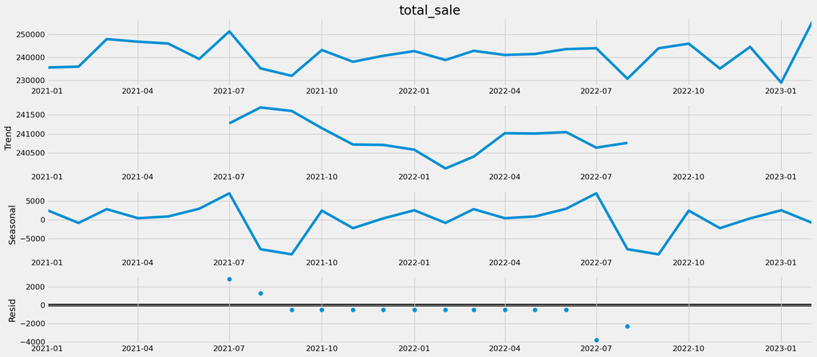

```python
# decompose time series into three distinct components: trend, seasonality, and noise.
from pylab import rcParams
rcParams['figure.figsize'] = 18, 8
decomposition = sm.tsa.seasonal_decompose(total_sales, model='additive')
fig = decomposition.plot()
plt.show()
```